# Chapter 2: Introduction to R

This statement is intentionally vague: as a data scientist, it will be your job to propose hypotheses about the data, and then to use the data to address your hypotheses. This is a creative, iterative, (and fun) process.

In this first lab I will propose four hypotheses for you. You must address these hypotheses with the suggested approaches. The approach will be to produce one plot for each hypothesis in a 2 by 2 set of plots. Discuss your findings for each case, including: whether the data supports or rejects the hypothesis, and to what degree the hypothesis is rejected or supported. After addressing the four hypotheses, I would like for you to propose at least one more hypothesis, and develop a methodology. Brevity matters, and less is best. Produce a single plot upon which to base your answer. Long answers will be given little credit. For this last part, you will be graded on the “interest” of the hypothesis, your approach to address it, and your discussion.

**Hypothesis 1. The tuition at the best colleges, as indicated by `Elite`, is higher than that at other colleges.**  
**Methodology:** Use one-over-other horizontal red boxplots of `Outstate` for elite and non-elite colleges. Title and label the axes of this plot thoughtfully. Carefully use this single plot to address this hypothesis. Can you be precise about the word *higher* ?

**Hypothesis 2. The enrollment rate at the best colleges, as indicated by `Elite`, is higher than that at other colleges.**  
**Methodology:** Create a new variable called `EnrollRate`, using `Enroll` and `Accept`. Use the `attach()` function to make your code cleaner. Use one-over-other horizontal green boxplots of `EnrollRate` for elite and non-elite colleges. Title and label the axes of this plot thoughtfully. Carefully use this single plot to address this hypothesis. Can you be precise about the word *higher* ? Can you comment on the presence of outliers in the boxplots? The enrollment rate is the fraction of accepted students who enrolled.

**Hypothesis 3. The number of applications per enrolled student is higher at elite colleges than other colleges.** **Methodology:** Use one-over-other horizontal blue boxplots of applications per enrolled student for elite and non-elite colleges. Title and label the axes of this plot thoughtfully. Carefully use this single plot to address this hypothesis. Can you be precise about the word *higher* ? Can you comment on the presence of outliers in the boxplots?

**Hypothesis 4. The fraction of alumni who donate is higher at elite colleges than other colleges.** **Methodology:** Use one-over-other horizontal cyan boxplots of `perc.alumni` for elite and non-elite colleges. Title and label the axes of this plot thoughtfully. Carefully use this single plot to address this hypothesis. Can you be precise about the word *higher* ?

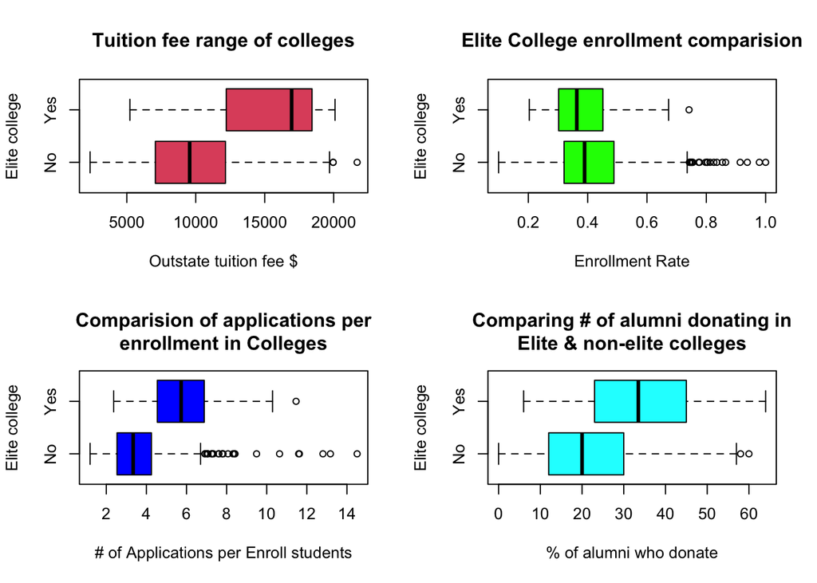

```r
EnrollRate = Enroll/Accept

par(mfrow = c(2, 2))
plot(Elite, Outstate, horizontal=T, ylab="Elite college", xlab="Outstate tuition fee $",
     main="Tuition fee range of colleges", col=2)
plot(Elite, EnrollRate, horizontal=T, ylab="Elite college", xlab="Enrollment Rate",
     main="Elite College enrollment comparision", col="green")
plot(Elite, Apps/Enroll, horizontal=T, ylab="Elite college", xlab="# of Applications per Enroll students",
     main="Comparision of applications per\nenrollment in Colleges", col="blue")
plot(Elite, perc.alumni, horizontal=T, ylab="Elite college", xlab="% of alumni who donate",
     main="Comparing # of alumni donating in\nElite & non-elite colleges", col="cyan")
```

##### Conclusion on *Hypothesis 1*

This is true. The minimum tuition of elite colleges is $5000 which is higher than approx 15% of non-elite colleges. The median fee of elite colleges is at $17000 approximately while for non elite its $10000. 75% (IRQ + Upper quartile) of elite colleges fee is greater than $13000 while 75% non-elite colelges have fees less than $13000. Hence, tuition in higher in Elite colleges in general as observed.

##### Conclusion on *Hypothesis 2*

This is false. Although, from plot, the median and majority (IQR 50%) of both elite and non-elite fall under same range with similar median, we can observe that the median and IQR for elite colleges is slightly less than non-elite college enrollment. When we look at lower and upper quartiles, the highest enrollment rate in elite colleges lower than that of non-elite colleges except for one outlier. The lower quartile shows that the enrollment rate for some non-elite colleges is lesser than elite once but this could be because of too many applicants in these non-elite application because of low entry standards.

##### Conclusion on *Hypothesis 3*

This is true, from the plot majority (75%) of elite colleges have atleast 4 applicants per enrolled students. For non elite 75% fall below 4. Again here we can observe some outliers similar to Enrollment Rate graph. These outliers just prove that some non-elite colleges have very low bar set for students to apply which is why a lot of students apply resulting in high enrolment rate. Overall, elite colleges have higher number of application per enrolled student showing competition.

##### Conclusion on *Hypothesis 4*

This is true, from the plot, 50% of elite colleges have more alumni donating than 80% of non-elite colleges.The distribution of the box plot quartiles are even for elite colleges which shows that as the eliteness of a college increases the alumni donating also proportionally increses. For non-elite colleges, 75% of alumni donating is below 30% and distributed evenly. There are 25% colleges which have significantly greater alum donations than the other 75%. This shows the transition of a non-elite college to an elite one.

##### *Hypothesis Proposal - The student faculty ratio is better for elite colleges*

**Methodology:** Use one-over-other horizontal boxplots of `S.F.Ratio` for elite and non-elite colleges?